# STAT 545 HW 02

Elijah Willie

September 25, 2018

## Introduction

In this document, I will be exploring the gapminder data further. I will be computing its class, how many variables, and how many obeservations. I will also be interested in the types of variable present and some summary statistics about them. I will also be looking at some variables in more detials by doing some graphical analyses. Hope you find this document eventful.

### load in the required libraries

```r
suppressMessages(library("tidyverse"))
library(gapminder)
```

## Smell the test data

### Summarize the data

|  | country | continent | year | lifeExp | pop | gdpPercap |
| --- | --- | --- | --- | --- | --- | --- |
|  | Afghanistan: 12 | Africa :624 | Min. :1952 | Min. :23.60 | Min. :6.001e+04 | Min. : 241.2 |
|  | Albania : 12 | Americas:300 | 1st Qu.:1966 | 1st Qu.:48.20 | 1st Qu.:2.794e+06 | 1st Qu.: 1202.1 |
|  | Algeria : 12 | Asia :396 | Median :1980 | Median :60.71 | Median :7.024e+06 | Median : 3531.8 |
|  | Angola : 12 | Europe :360 | Mean :1980 | Mean :59.47 | Mean :2.960e+07 | Mean : 7215.3 |
|  | Argentina : 12 | Oceania : 24 | 3rd Qu.:1993 | 3rd Qu.:70.85 | 3rd Qu.:1.959e+07 | 3rd Qu.: 9325.5 |
|  | Australia : 12 | NA | Max. :2007 | Max. :82.60 | Max. :1.319e+09 | Max. :113523.1 |
|  | (Other) :1632 | NA | NA | NA | NA | NA |

### Get the type of the data

```r
typeof(gapminder)
```

```
## [1] "list"
```

### Get the data class

```r
class(gapminder)
```

```
## [1] "tbl_df"     "tbl"        "data.frame"
```

### Get the number of variables

```r
ncol(gapminder)
```

```
## [1] 6
```

### Get the number of observations

```r
nrow(gapminder)
```

```
## [1] 1704
```

### Get the types of variables

I will be using the sapply function that applies a function to each column of the dataframe and prints the output. For the function, I will be using the class function which returns the class of each of the columns of the gapminder data

```r
 knitr::kable(sapply(gapminder, class))
```

|  | x |
| --- | --- |
| country | factor |
| continent | factor |
| year | integer |
| lifeExp | numeric |
| pop | integer |
| gdpPercap | numeric |

### It is also interesting to do summaries of some variables stratified by a grouping variable.

### I will group the gapminder dataset by continent

```r
oldops <-options(tibble.width=Inf, tibble.print_max=Inf)
gm_byContinent <- group_by(gapminder,continent)
knitr::kable(head(gm_byContinent))
```

| country | continent | year | lifeExp | pop | gdpPercap |
| --- | --- | --- | --- | --- | --- |
| Afghanistan | Asia | 1952 | 28.801 | 8425333 | 779.4453 |
| Afghanistan | Asia | 1957 | 30.332 | 9240934 | 820.8530 |
| Afghanistan | Asia | 1962 | 31.997 | 10267083 | 853.1007 |
| Afghanistan | Asia | 1967 | 34.020 | 11537966 | 836.1971 |
| Afghanistan | Asia | 1972 | 36.088 | 13079460 | 739.9811 |
| Afghanistan | Asia | 1977 | 38.438 | 14880372 | 786.1134 |

### Summarize the data using the grouped variable

```r
 knitr::kable(summary(gm_byContinent))
```

|  | country | continent | year | lifeExp | pop | gdpPercap |
| --- | --- | --- | --- | --- | --- | --- |
|  | Afghanistan: 12 | Africa :624 | Min. :1952 | Min. :23.60 | Min. :6.001e+04 | Min. : 241.2 |
|  | Albania : 12 | Americas:300 | 1st Qu.:1966 | 1st Qu.:48.20 | 1st Qu.:2.794e+06 | 1st Qu.: 1202.1 |
|  | Algeria : 12 | Asia :396 | Median :1980 | Median :60.71 | Median :7.024e+06 | Median : 3531.8 |
|  | Angola : 12 | Europe :360 | Mean :1980 | Mean :59.47 | Mean :2.960e+07 | Mean : 7215.3 |
|  | Argentina : 12 | Oceania : 24 | 3rd Qu.:1993 | 3rd Qu.:70.85 | 3rd Qu.:1.959e+07 | 3rd Qu.: 9325.5 |
|  | Australia : 12 | NA | Max. :2007 | Max. :82.60 | Max. :1.319e+09 | Max. :113523.1 |
|  | (Other) :1632 | NA | NA | NA | NA | NA |

### We can aslo do a pairs plot for variables of interest in our dataset

```r
library(GGally)
```

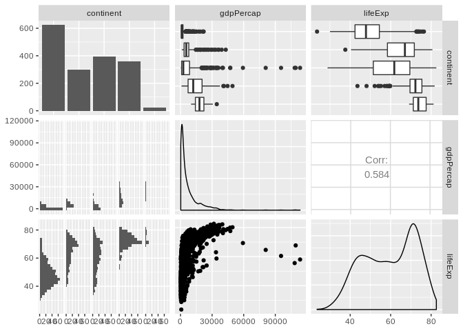

```r
gm_pairs <- select(gapminder, continent, gdpPercap, lifeExp)
ggpairs(gm_pairs)
```

## Explore individual variables

### For this analyses I will be picking continent, lifeExp, and gdpPercap

### Get some data summary for gdpPercap for each continent

```r
summarize(gm_byContinent,min(gdpPercap),median(gdpPercap),IQR(gdpPercap),mean(gdpPercap),sd(gdpPercap),max(gdpPercap))
```

```
## # A tibble: 5 x 7
##   continent `min(gdpPercap)` `median(gdpPercap)` `IQR(gdpPercap)`
##   <fct>                <dbl>               <dbl>            <dbl>
## 1 Africa                241.               1192.            1616.
## 2 Americas             1202.               5466.            4402.
## 3 Asia                  331                2647.            7492.
## 4 Europe                974.              12082.           13248.
## 5 Oceania             10040.              17983.            8072.
##   `mean(gdpPercap)` `sd(gdpPercap)` `max(gdpPercap)`
##               <dbl>           <dbl>            <dbl>
## 1             2194.           2828.           21951.
## 2             7136.           6397.           42952.
## 3             7902.          14045.          113523.
## 4            14469.           9355.           49357.
## 5            18622.           6359.           34435.
```

### Overlay a histogram with a density plot for gdpPercap

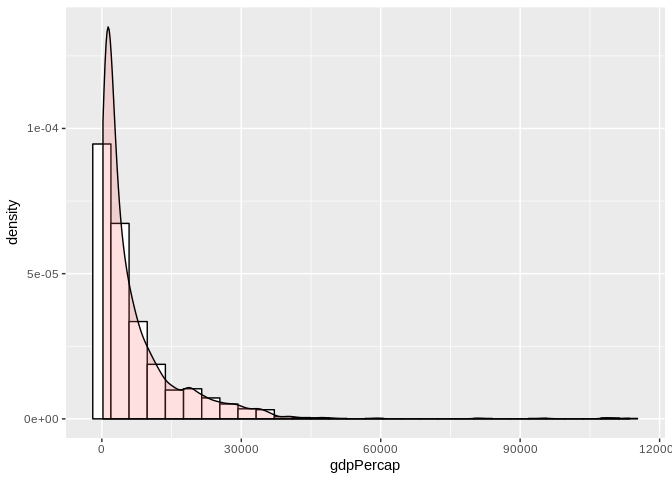

```r
ggplot(gapminder, aes(x=gdpPercap)) + geom_histogram(aes(y=..density..), colour="black", fill="white") + geom_density(alpha=.2, fill="#FF6666")
```

### Get some data summary for lifeExp

```r
 knitr::kable(summarize(gm_byContinent,min(lifeExp),median(lifeExp),IQR(lifeExp),mean(lifeExp),sd(lifeExp),max(lifeExp)))
```

| continent | min(lifeExp) | median(lifeExp) | IQR(lifeExp) | mean(lifeExp) | sd(lifeExp) | max(lifeExp) |
| --- | --- | --- | --- | --- | --- | --- |
| Africa | 23.599 | 47.7920 | 12.0390 | 48.86533 | 9.150210 | 76.442 |
| Americas | 37.579 | 67.0480 | 13.2895 | 64.65874 | 9.345088 | 80.653 |
| Asia | 28.801 | 61.7915 | 18.0790 | 60.06490 | 11.864532 | 82.603 |
| Europe | 43.585 | 72.2410 | 5.8805 | 71.90369 | 5.433178 | 81.757 |
| Oceania | 69.120 | 73.6650 | 6.3475 | 74.32621 | 3.795611 | 81.235 |

### Overlay a histogram with a density plot for lifeExp

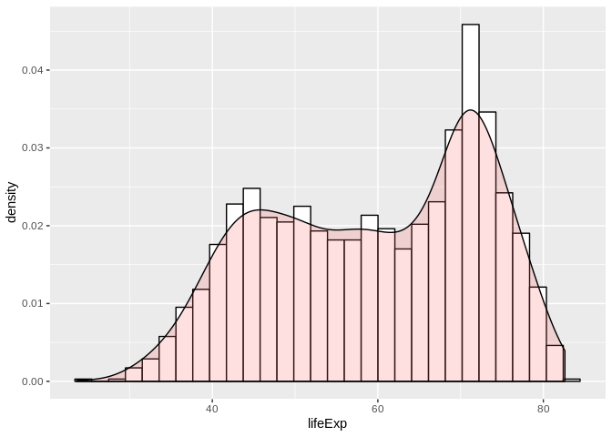

```r
ggplot(gapminder, aes(x=lifeExp)) + geom_histogram(aes(y=..density..), colour="black", fill="white") + geom_density(alpha=.2, fill="#FF6666")
```

## Explore various plot types

### Boxplots

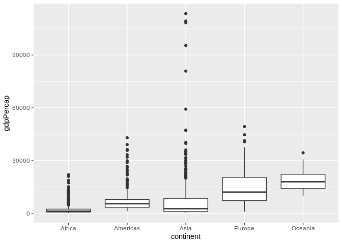

```r
ggplot(gapminder, aes(continent, gdpPercap)) + geom_boxplot()
```

#### Now do a boxplot again, but with a log_10 transform of the gdpPercap variable

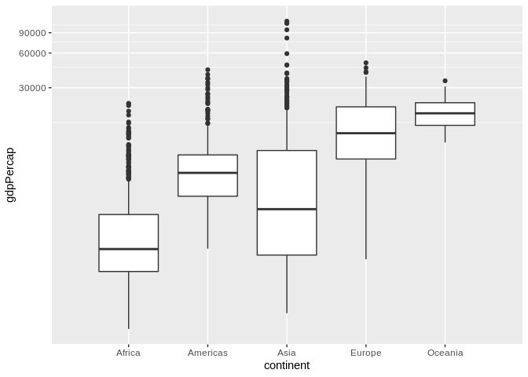

```r
ggplot(gapminder, aes(continent, gdpPercap)) + coord_trans(y="log10") + geom_boxplot()
```

### Boxplot for lifeExp

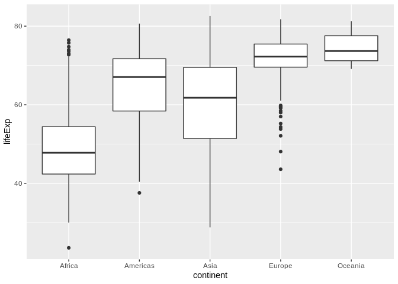

```r
ggplot(gapminder, aes(continent, lifeExp)) + geom_boxplot()
```

#### Now instead of transforming it everytime, I will transform it and store it in a new variable

```r
gapminder <- mutate(gapminder, log10GdpPercap =log10(gdpPercap))
```

### Histograms

#### Plot a stacked historam of log(gdpPercap) as a function of continent

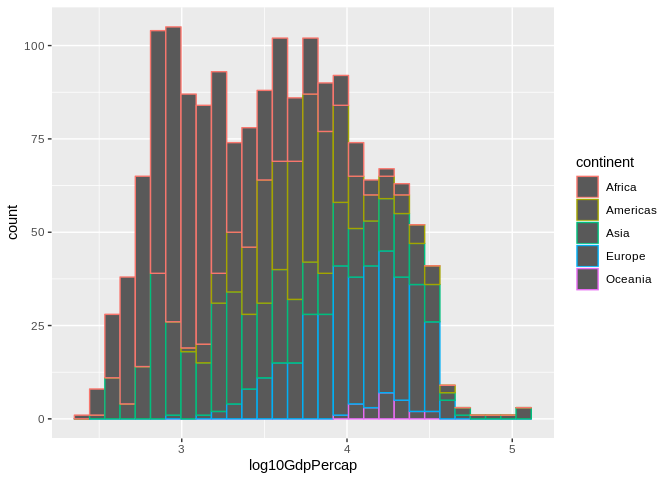

```r
ggplot(gapminder,aes(x=log10GdpPercap, color=continent))+ geom_histogram()
```

#### You can also fill the histogram bars with colors

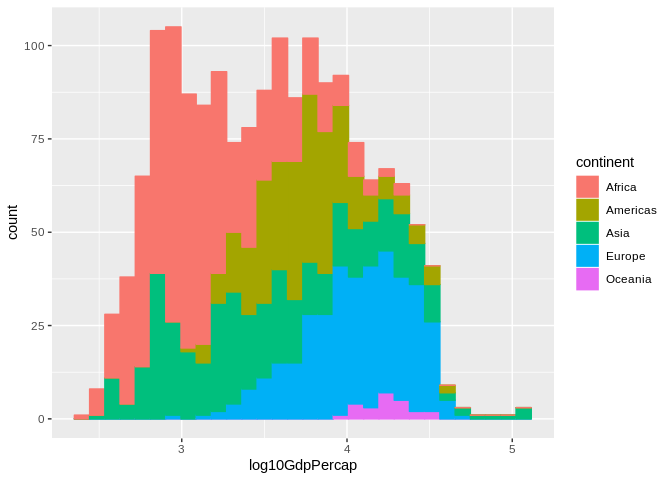

```r
ggplot(gapminder,aes(x=log10GdpPercap, color=continent))+ geom_histogram(aes(fill = continent))
```

#### You can also stack the histograms if you do not wish to have them overlaying each other

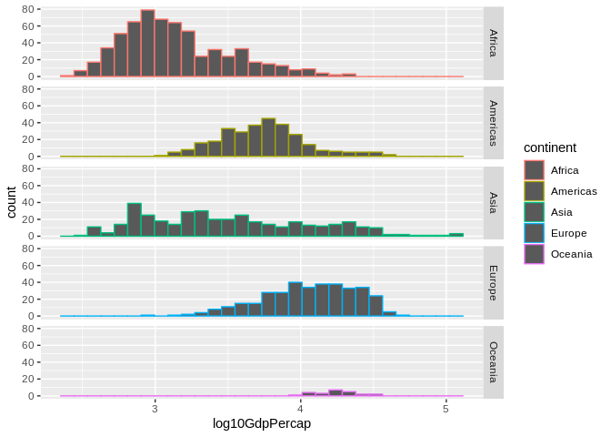

```r
ggplot(gapminder,aes(x=log10GdpPercap, color=continent))+ geom_histogram() + facet_grid(continent ~ .)
```

#### You can also stack the histograms sideways

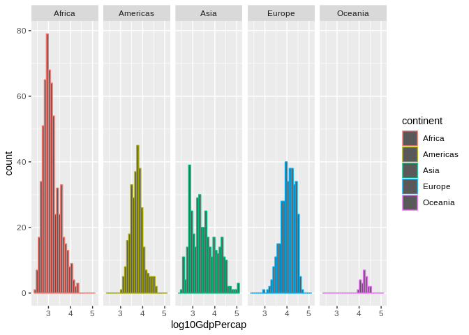

```r
ggplot(gapminder,aes(x=log10GdpPercap, color=continent))+ geom_histogram() + facet_grid(~continent)
```

#### Do the same for lifeExp

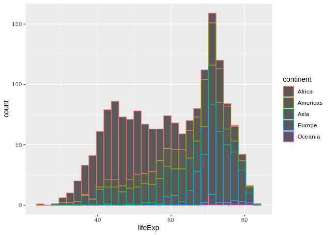

```r
ggplot(gapminder,aes(x=lifeExp, color=continent))+ geom_histogram()
```

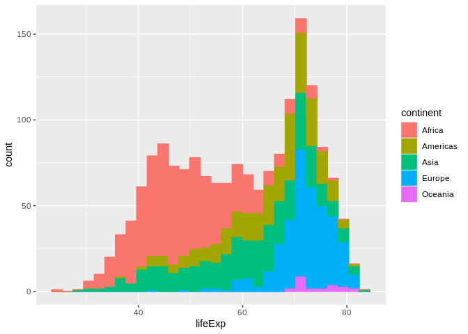

```r
ggplot(gapminder,aes(x=lifeExp, color=continent))+ geom_histogram(aes(fill = continent))
```

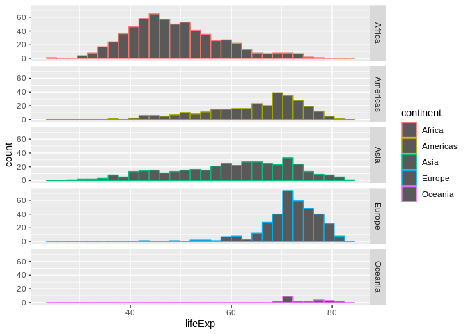

```r
ggplot(gapminder,aes(x=lifeExp, color=continent))+ geom_histogram() + facet_grid(continent ~ .)
```

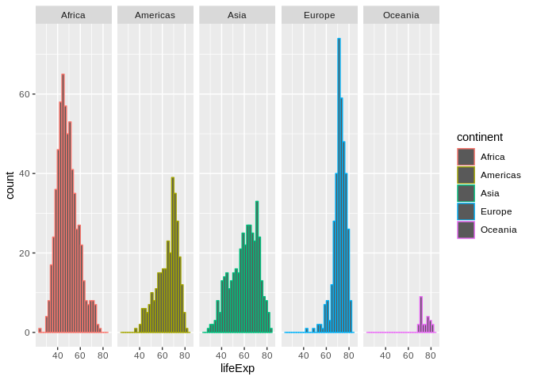

```r
ggplot(gapminder,aes(x=lifeExp, color=continent))+ geom_histogram() + facet_grid(~continent)
```

#### Do a scatterplot of logGdpPercap vs lifeExp

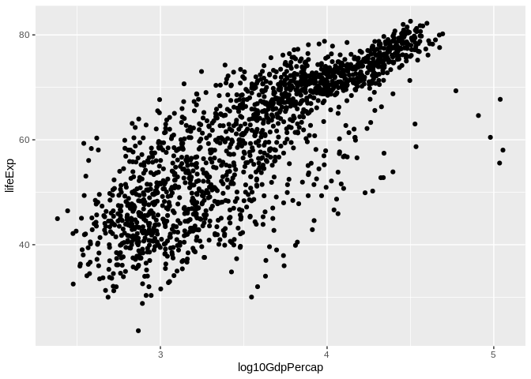

```r
my_plot <- ggplot(gapminder, aes(log10GdpPercap, lifeExp))
my_plot + geom_point()
```

#### Now color the plot by continent

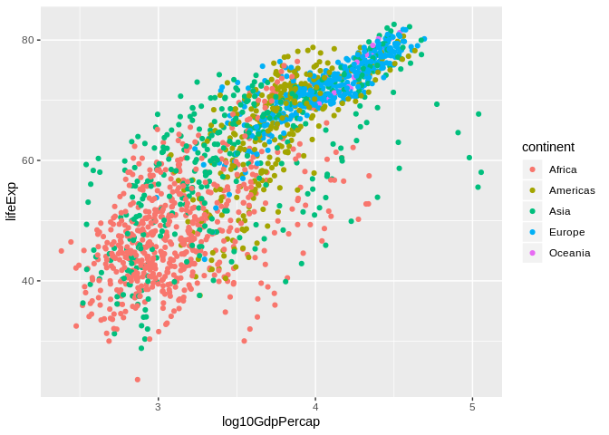

```r
my_plot + geom_point(aes(color = continent))
```

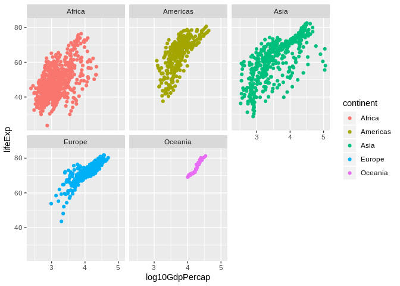

```r
my_plot + geom_point(aes(color = continent)) + facet_wrap(~continent)
```

## Use select and piping functions

### I will explore the life expectancy variable for the year 2007. First filter the data to just 2007.

```r
gapminder07 <- filter(gapminder, year == 2007)
 knitr::kable(head(gapminder07))
```

| country | continent | year | lifeExp | pop | gdpPercap | log10GdpPercap |
| --- | --- | --- | --- | --- | --- | --- |
| Afghanistan | Asia | 2007 | 43.828 | 31889923 | 974.5803 | 2.988818 |
| Albania | Europe | 2007 | 76.423 | 3600523 | 5937.0295 | 3.773569 |
| Algeria | Africa | 2007 | 72.301 | 33333216 | 6223.3675 | 3.794025 |
| Angola | Africa | 2007 | 42.731 | 12420476 | 4797.2313 | 3.680991 |
| Argentina | Americas | 2007 | 75.320 | 40301927 | 12779.3796 | 4.106510 |
| Australia | Oceania | 2007 | 81.235 | 20434176 | 34435.3674 | 4.537005 |

### Calculate median life expectancy, first overall, and then by continent.

```r
 knitr::kable(summarize(gapminder07, median(lifeExp)))
```

| median(lifeExp) |
| --- |
| 71.9355 |

```r
by_cont <- group_by(gapminder07, continent)
knitr::kable(summarise(by_cont, median(lifeExp)))
```

| continent | median(lifeExp) |
| --- | --- |
| Africa | 52.9265 |
| Americas | 72.8990 |
| Asia | 72.3960 |
| Europe | 78.6085 |
| Oceania | 80.7195 |

### We can compute the median life expectancies.

```r
medL <- summarize(by_cont, median(lifeExp))
```

### We can also commpute the median life expectancy using chaining and piping

```r
medL.2 <- gapminder %>%
  filter(year == 2007) %>%
  group_by(continent) %>%
  summarise(medLifeExp = median(lifeExp))
```

### We can visualize the median life expectancies

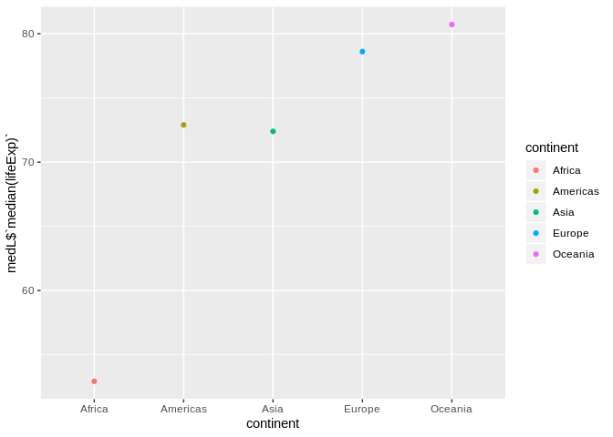

```r
ggplot(medL, aes(continent, y = medL$`median(lifeExp)`)) + geom_point(aes(color = continent))
```

### We can actually combine all of this into a set of chaining and piping command that does the plot at the end

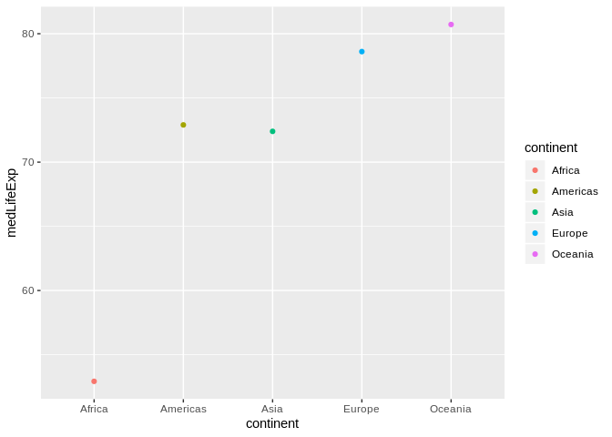

```r
gapminder %>%
  filter(year == 2007) %>%
  group_by(continent) %>%
  summarise(medLifeExp = median(lifeExp)) %>%
  ggplot(aes(continent, y = medLifeExp)) + geom_point(aes(color = continent))
```

## But I want to do more

### Evaluate the given code

```r
result <- filter(gapminder, country == c("Rwanda", "Afghanistan"))
 knitr::kable(result)
```

| country | continent | year | lifeExp | pop | gdpPercap | log10GdpPercap |
| --- | --- | --- | --- | --- | --- | --- |
| Afghanistan | Asia | 1957 | 30.332 | 9240934 | 820.8530 | 2.914265 |
| Afghanistan | Asia | 1967 | 34.020 | 11537966 | 836.1971 | 2.922309 |
| Afghanistan | Asia | 1977 | 38.438 | 14880372 | 786.1134 | 2.895485 |
| Afghanistan | Asia | 1987 | 40.822 | 13867957 | 852.3959 | 2.930641 |
| Afghanistan | Asia | 1997 | 41.763 | 22227415 | 635.3414 | 2.803007 |
| Afghanistan | Asia | 2007 | 43.828 | 31889923 | 974.5803 | 2.988818 |
| Rwanda | Africa | 1952 | 40.000 | 2534927 | 493.3239 | 2.693132 |
| Rwanda | Africa | 1962 | 43.000 | 3051242 | 597.4731 | 2.776318 |
| Rwanda | Africa | 1972 | 44.600 | 3992121 | 590.5807 | 2.771279 |
| Rwanda | Africa | 1982 | 46.218 | 5507565 | 881.5706 | 2.945257 |
| Rwanda | Africa | 1992 | 23.599 | 7290203 | 737.0686 | 2.867508 |
| Rwanda | Africa | 2002 | 43.413 | 7852401 | 785.6538 | 2.895231 |

The analyst did not. The proper way to do it is shown below. As we can see, the difference is that we get double the number of rows so initially the analyst only obtains haft the total result, but with the second attempt below, the full result is obtained.

```r
result2 <- filter(gapminder, country =="Rwanda"| country ==  "Afghanistan")
 knitr::kable(result2)
```

| country | continent | year | lifeExp | pop | gdpPercap | log10GdpPercap |
| --- | --- | --- | --- | --- | --- | --- |
| Afghanistan | Asia | 1952 | 28.801 | 8425333 | 779.4453 | 2.891786 |
| Afghanistan | Asia | 1957 | 30.332 | 9240934 | 820.8530 | 2.914265 |
| Afghanistan | Asia | 1962 | 31.997 | 10267083 | 853.1007 | 2.931000 |
| Afghanistan | Asia | 1967 | 34.020 | 11537966 | 836.1971 | 2.922309 |
| Afghanistan | Asia | 1972 | 36.088 | 13079460 | 739.9811 | 2.869221 |
| Afghanistan | Asia | 1977 | 38.438 | 14880372 | 786.1134 | 2.895485 |
| Afghanistan | Asia | 1982 | 39.854 | 12881816 | 978.0114 | 2.990344 |
| Afghanistan | Asia | 1987 | 40.822 | 13867957 | 852.3959 | 2.930641 |
| Afghanistan | Asia | 1992 | 41.674 | 16317921 | 649.3414 | 2.812473 |
| Afghanistan | Asia | 1997 | 41.763 | 22227415 | 635.3414 | 2.803007 |
| Afghanistan | Asia | 2002 | 42.129 | 25268405 | 726.7341 | 2.861375 |
| Afghanistan | Asia | 2007 | 43.828 | 31889923 | 974.5803 | 2.988818 |
| Rwanda | Africa | 1952 | 40.000 | 2534927 | 493.3239 | 2.693132 |
| Rwanda | Africa | 1957 | 41.500 | 2822082 | 540.2894 | 2.732626 |
| Rwanda | Africa | 1962 | 43.000 | 3051242 | 597.4731 | 2.776318 |
| Rwanda | Africa | 1967 | 44.100 | 3451079 | 510.9637 | 2.708390 |
| Rwanda | Africa | 1972 | 44.600 | 3992121 | 590.5807 | 2.771279 |
| Rwanda | Africa | 1977 | 45.000 | 4657072 | 670.0806 | 2.826127 |
| Rwanda | Africa | 1982 | 46.218 | 5507565 | 881.5706 | 2.945257 |
| Rwanda | Africa | 1987 | 44.020 | 6349365 | 847.9912 | 2.928391 |
| Rwanda | Africa | 1992 | 23.599 | 7290203 | 737.0686 | 2.867508 |
| Rwanda | Africa | 1997 | 36.087 | 7212583 | 589.9445 | 2.770811 |
| Rwanda | Africa | 2002 | 43.413 | 7852401 | 785.6538 | 2.895231 |
| Rwanda | Africa | 2007 | 46.242 | 8860588 | 863.0885 | 2.936055 |